# PA1_template

## Loading and preprocessing the data

First we load the data from the `activity.csv`. We use `dplyr` library for easier manipulation with the data. The dates are handled with the `lubridate` library.

```r
library(dplyr)
library(lubridate)
activity <- read.csv("/Users/arunasingh/Downloads/Projects/R Projects/activity.csv", header = TRUE, sep = ",", na.strings = "NA")
```

## What is mean total number of steps taken per day?

First, we calculate total number of steps taken each day; we omit the incomplete cases, i.e., when the number of steps is not reported (missing in the data).

```r
activity_steps <- subset(activity, complete.cases(activity)) %>%
  group_by(date) %>% summarise(total= sum(steps))
```

Next, we make a histogram of the total number of steps in order to see its variance and distribution.

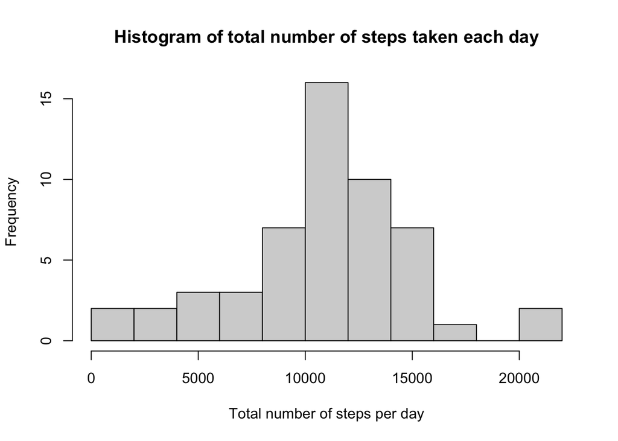

```r
hist(activity_steps$total, breaks = 10, main = "Histogram of total number of steps taken each day", xlab = "Total number of steps per day")
```

Finally, we compute *mean* and *median* values of the total number of steps.

```r
mean(activity_steps$total)
```

```
## [1] 10766.19
```

```r
median(activity_steps$total)
```

```
## [1] 10765
```

## What is the average daily activity pattern?

Below, we can see as the number of steps changes throughout the day (averaged across all the days).

```r
steps_per_interval <- activity %>%
  group_by(interval) %>%
  summarize(mean = mean(steps, na.rm = TRUE))
```

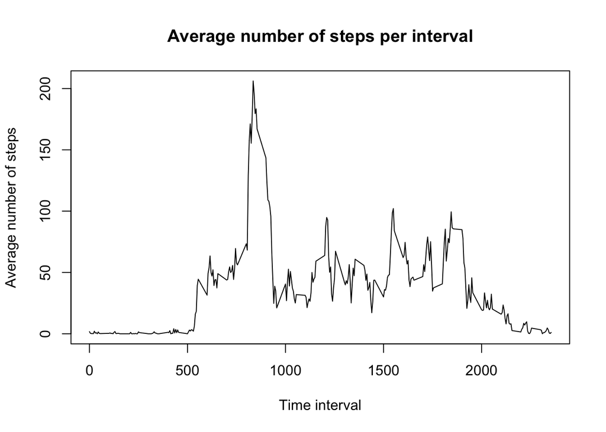

```r
plot(steps_per_interval, type = 'l', main = "Average number of steps per interval",
     xlab = "Time interval", ylab = "Average number of steps")
```

The 5-minute interval with maximum number of steps is as follows:

```r
max_steps <- max(steps_per_interval$mean)
subset(steps_per_interval, mean == max_steps)$interval
```

```
## [1] 835
```

## Imputing missing values

The total number of rows with missing values:

```r
sum(!complete.cases(activity))
```

```
## [1] 2304
```

We fill the missing values of steps with the average number of steps for the given 5-minute interval.

```r
interval_means <- sapply(activity$interval,
                         function(x) subset(steps_per_interval, interval == x)$mean)
missing <- is.na(activity$steps)
activity_imputed <- activity
activity_imputed[missing, ]$steps <- interval_means[missing]
```

Next, we calculate total number of steps on the imputed data and visualize the histogram in order to compare it with the original data.

```r
total_steps_imputed <- activity_imputed %>%
  group_by(date) %>%
  summarize(total = sum(steps))
```

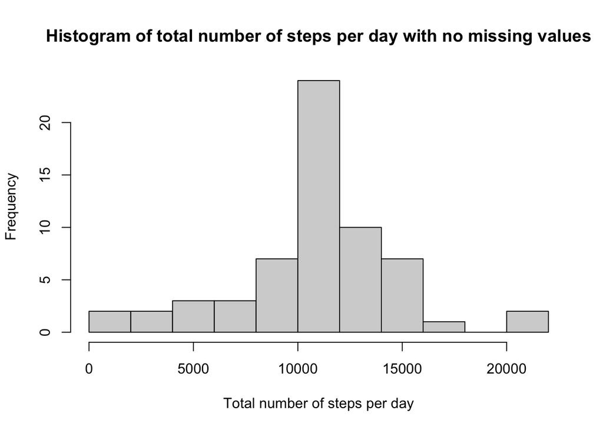

```r
hist(total_steps_imputed$total, breaks = 10, main =
       "Histogram of total number of steps per day with no missing values",
     xlab = "Total number of steps per day")
```

For the sake of comparison, we also compute new *mean* and *median* values of the total number of steps.

```r
inputed <- total_steps_imputed[!is.na(total_steps_imputed$total), ]
inputed
```

```
## # A tibble: 61 x 2
##    date        total
##    <chr>       <dbl>
##  1 2012-10-01 10766.
##  2 2012-10-02   126
##  3 2012-10-03 11352
##  4 2012-10-04 12116
##  5 2012-10-05 13294
##  6 2012-10-06 15420
##  7 2012-10-07 11015
##  8 2012-10-08 10766.
##  9 2012-10-09 12811
## 10 2012-10-10  9900
## # … with 51 more rows
```

```r
mean(inputed$total)
```

```
## [1] 10766.19
```

```r
median(inputed$total)
```

```
## [1] 10766.19
```

We can see that the chosen strategy has no effect on the mean; the median is a bit higher and now equal to the mean.

## Are there differences in activity patterns between weekdays and weekends?

```r
day_in_week <- function(date) {
  wday <- wday(date)
  is_weekend <- wday == 1 | wday == 6

  day_in_week <- character(length = length(date))
  day_in_week[is_weekend] <- "weekend"
  day_in_week[!is_weekend] <- "weekday"

  return(as.factor(day_in_week))
}
activity_imputed <- activity_imputed %>% mutate(day_in_week = day_in_week(date))
```

Finally, we plot the time series of number of steps per intervals comparing the weekdays and weekends. We use `ggplot` library for this purpose.

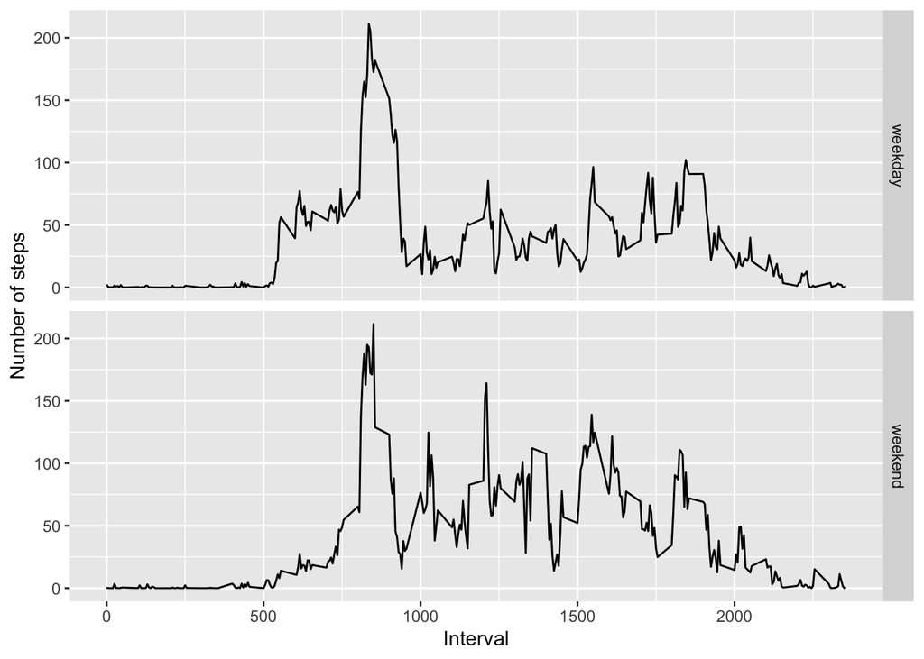

```r
steps_per_interval_imputed <- activity_imputed %>%
  group_by(interval, day_in_week) %>%
  summarize(mean = mean(steps, na.rm = TRUE))
library(ggplot2)
g <- ggplot(steps_per_interval_imputed, aes(interval, mean))
g <- g + facet_grid(day_in_week ~ .)
g <- g + geom_line()
g + xlab("Interval") + ylab("Number of steps")
```